# KPMG's client: Sprocket Central data analysis

*By: [Aaron Nhu](https://www.linkedin.com/in/aaronnhu/) & [Hoang Vu](https://www.linkedin.com/in/hoangvu97/)*

### Introduction

This is the project hosted by [KPMG Virtual Internship Program](https://www.insidesherpa.com/virtual-internships/theme/m7W4GMqeT3bh9Nb2c/KPMG-Data-Analytics-Virtual-Internship/). Our tasks are to clean and explore one of KPMG's clients, Sprocket Central Pty Ltd, a medium size bikes & cycling accessories organisation. In this report, we will dive into the company's data and look for key intelligence to make suggestions that can help to improve the company's performance in the future.

```python
import pandas as pd
import numpy as np
import matplotlib.pyplot as plt
%matplotlib inline
```

```python
trans_df = pd.read_excel('KPMG_VI_New_raw_data_update_final.xlsx', sheet_name = 'Transactions', skiprows = 1)
```

```python
trans_df.head()
```

|  | transaction_id | product_id | customer_id | transaction_date | online_order | order_status | brand | product_line | product_class | product_size | list_price | standard_cost | product_first_sold_date |
| --- | --- | --- | --- | --- | --- | --- | --- | --- | --- | --- | --- | --- | --- |
| 0 | 1 | 2 | 2950 | 2017-02-25 | 0.0 | Approved | Solex | Standard | medium | medium | 71.49 | 53.62 | 41245.0 |
| 1 | 2 | 3 | 3120 | 2017-05-21 | 1.0 | Approved | Trek Bicycles | Standard | medium | large | 2091.47 | 388.92 | 41701.0 |
| 2 | 3 | 37 | 402 | 2017-10-16 | 0.0 | Approved | OHM Cycles | Standard | low | medium | 1793.43 | 248.82 | 36361.0 |
| 3 | 4 | 88 | 3135 | 2017-08-31 | 0.0 | Approved | Norco Bicycles | Standard | medium | medium | 1198.46 | 381.10 | 36145.0 |
| 4 | 5 | 78 | 787 | 2017-10-01 | 1.0 | Approved | Giant Bicycles | Standard | medium | large | 1765.30 | 709.48 | 42226.0 |

```python
trans_df.isna().sum()
```

```
transaction_id               0
product_id                   0
customer_id                  0
transaction_date             0
online_order               360
order_status                 0
brand                      197
product_line               197
product_class              197
product_size               197
list_price                   0
standard_cost              197
product_first_sold_date    197
dtype: int64
```

```python
trans_df = trans_df.drop(trans_df[trans_df.brand.isna()].index)
```

```python
demo_df = pd.read_excel('KPMG_VI_New_raw_data_update_final.xlsx', sheet_name = 'CustomerDemographic', skiprows = 1)
demo_df.head()
```

|  | customer_id | first_name | last_name | gender | past_3_years_bike_related_purchases | DOB | job_title | job_industry_category | wealth_segment | deceased_indicator | default | owns_car | tenure |
| --- | --- | --- | --- | --- | --- | --- | --- | --- | --- | --- | --- | --- | --- |
| 0 | 1 | Laraine | Medendorp | F | 93 | 1953-10-12 | Executive Secretary | Health | Mass Customer | N | "' | Yes | 11.0 |
| 1 | 2 | Eli | Bockman | Male | 81 | 1980-12-16 | Administrative Officer | Financial Services | Mass Customer | N | <script>alert('hi')</script> | Yes | 16.0 |
| 2 | 3 | Arlin | Dearle | Male | 61 | 1954-01-20 | Recruiting Manager | Property | Mass Customer | N | 2018-02-01 00:00:00 | Yes | 15.0 |
| 3 | 4 | Talbot | NaN | Male | 33 | 1961-10-03 | NaN | IT | Mass Customer | N | () { _; } >_[$($())] { touch /tmp/blns.shellsh... | No | 7.0 |
| 4 | 5 | Sheila-kathryn | Calton | Female | 56 | 1977-05-13 | Senior Editor | NaN | Affluent Customer | N | NIL | Yes | 8.0 |

```python
demo_df.isna().sum()
```

```
customer_id                              0
first_name                               0
last_name                              125
gender                                   0
past_3_years_bike_related_purchases      0
DOB                                     87
job_title                              506
job_industry_category                  656
wealth_segment                           0
deceased_indicator                       0
default                                302
owns_car                                 0
tenure                                  87
dtype: int64
```

```python
demo_df = demo_df.drop(columns = ['default'])
```

```python
error_gender_DOB_tenure_cusid = demo_df[demo_df.gender == "U"].customer_id
```

```python
demo_df = demo_df.drop(demo_df[demo_df.DOB.isna()].index)
```

```python
demo_df['age'] = demo_df.DOB.apply(lambda x : pd.to_datetime('today').year - x.year)
```

```python
demo_df['gender'].replace(['F','Femal'],'Female',inplace=True)
demo_df['gender'].replace('M','Male',inplace=True)
```

```python
demo_df = demo_df.drop(demo_df[demo_df.DOB.isna()].index)
```

```python
demo_df = demo_df[demo_df.age < 100]
```

```python
addr_df = pd.read_excel('KPMG_VI_New_raw_data_update_final.xlsx', sheet_name = 'CustomerAddress', skiprows = 1)
addr_df.head()
```

|  | customer_id | address | postcode | state | country | property_valuation |
| --- | --- | --- | --- | --- | --- | --- |
| 0 | 1 | 060 Morning Avenue | 2016 | New South Wales | Australia | 10 |
| 1 | 2 | 6 Meadow Vale Court | 2153 | New South Wales | Australia | 10 |
| 2 | 4 | 0 Holy Cross Court | 4211 | QLD | Australia | 9 |
| 3 | 5 | 17979 Del Mar Point | 2448 | New South Wales | Australia | 4 |
| 4 | 6 | 9 Oakridge Court | 3216 | VIC | Australia | 9 |

```python
addr_df.isna().sum()
```

```
customer_id           0
address               0
postcode              0
state                 0
country               0
property_valuation    0
dtype: int64
```

```python
trans_df = trans_df.drop(['transaction_date','order_status','product_first_sold_date'],axis = 1)
```

```python
demo_df = demo_df.drop(['first_name','last_name','deceased_indicator','tenure'],axis=1)
```

```python
addr_df = addr_df.drop(['address','country','property_valuation'],axis=1)
```

```python
join_df = trans_df.set_index('customer_id').join(demo_df.set_index('customer_id')).join(addr_df.set_index('customer_id'))
join_df.head()
```

| customer_id | transaction_id | product_id | online_order | brand | product_line | product_class | product_size | list_price | standard_cost | gender | past_3_years_bike_related_purchases | DOB | job_title | job_industry_category | wealth_segment | owns_car | age | postcode | state |
| --- | --- | --- | --- | --- | --- | --- | --- | --- | --- | --- | --- | --- | --- | --- | --- | --- | --- | --- | --- |
| 1 | 94 | 86 | 0.0 | OHM Cycles | Standard | medium | medium | 235.63 | 125.07 | Female | 93.0 | 1953-10-12 | Executive Secretary | Health | Mass Customer | Yes | 67.0 | 2016.0 | New South Wales |
| 1 | 3765 | 38 | 1.0 | Solex | Standard | medium | medium | 1577.53 | 826.51 | Female | 93.0 | 1953-10-12 | Executive Secretary | Health | Mass Customer | Yes | 67.0 | 2016.0 | New South Wales |
| 1 | 5157 | 47 | 1.0 | Trek Bicycles | Road | low | small | 1720.70 | 1531.42 | Female | 93.0 | 1953-10-12 | Executive Secretary | Health | Mass Customer | Yes | 67.0 | 2016.0 | New South Wales |
| 1 | 9785 | 72 | 0.0 | Norco Bicycles | Standard | medium | medium | 360.40 | 270.30 | Female | 93.0 | 1953-10-12 | Executive Secretary | Health | Mass Customer | Yes | 67.0 | 2016.0 | New South Wales |
| 1 | 13424 | 2 | 0.0 | Solex | Standard | medium | medium | 71.49 | 53.62 | Female | 93.0 | 1953-10-12 | Executive Secretary | Health | Mass Customer | Yes | 67.0 | 2016.0 | New South Wales |

```python
join_df['profit'] = join_df.list_price - join_df.standard_cost
```

```python
#join_df.to_excel('Join tables.xlsx')
```

```python
sum_age = join_df.groupby('age').sum()
mean_age = join_df.groupby('age').mean()
```

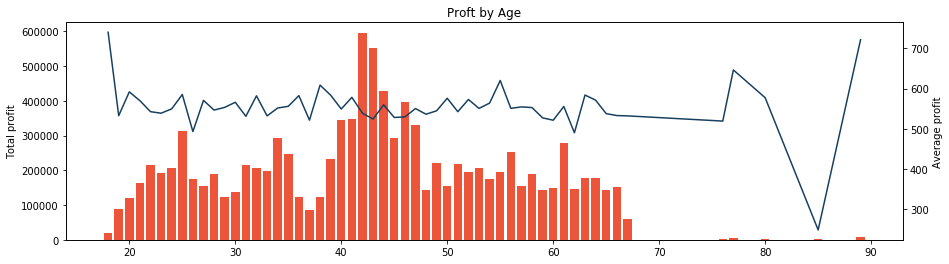

```python
fig, ax1 = plt.subplots(figsize = (15,4))
ax1.bar(sum_age.index,sum_age.profit, color = '#ED553B')
ax1.set_ylabel('Total profit')
ax2 = ax1.twinx()
ax2.plot(mean_age.index,mean_age.profit, color = '#173F5F')
ax2.set_ylabel('Average profit')
plt.title('Proft by Age')
plt.show()
```

The majority of buyers are in the age of 40 - 50. However, the average profit is the same across different ages. Therefore, therefore, they just need to focus on the strategy to increase sales in general, relardless of age specification.

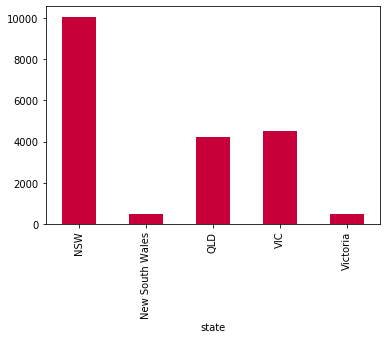

```python
join_df.groupby('state').count()['profit'].plot(kind = 'bar',color='#C70039')
```

The majority of buyers are from NSW state.

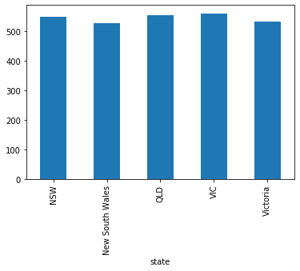

```python
join_df.groupby('state').mean()['profit'].plot(kind = 'bar')
```

However, the average profit relatively similar across different states. Therefore, there is no need to focus on a particular market as they just need to increase sales in all states.

```python
join_df.groupby(['state', 'product_line']).sum().head()
```

| state | product_line | transaction_id | product_id | online_order | list_price | standard_cost | past_3_years_bike_related_purchases | age | postcode |
| --- | --- | --- | --- | --- | --- | --- | --- | --- | --- |
| NSW | Mountain | 2163490 | 4406 | 118.0 | 133445.97 | 113388.00 | 10095.0 | 8858.0 | 486818.0 |
|  | Road | 19854224 | 88014 | 975.0 | 2011357.76 | 1303625.46 | 94902.0 | 81959.0 | 4595258.0 |
|  | Standard | 72475961 | 326325 | 3576.0 | 7986665.72 | 3843700.14 | 350261.0 | 304501.0 | 16809543.0 |
|  | Touring | 6289828 | 39792 | 307.0 | 1004393.72 | 337672.53 | 29989.0 | 25621.0 | 1434439.0 |
| New South Wales | Mountain | 107197 | 159 | 5.0 | 5627.72 | 4750.07 | 460.0 | 346.0 | 21325.0 |

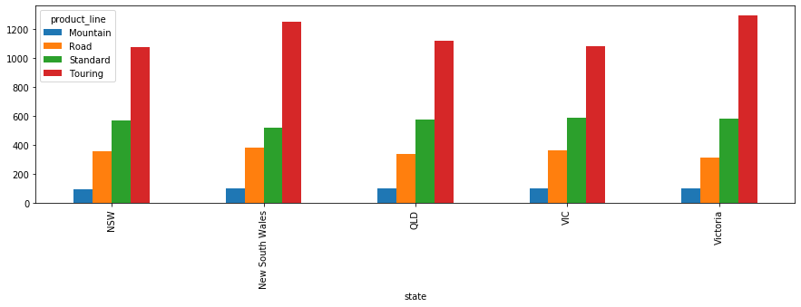

```python
join_df.groupby(['state', 'product_line']).mean()['profit'].unstack().plot(kind = 'bar', figsize = (15,4))
```

On average, the touring segment brings the highest profit for the company.

```python
join_df.groupby(['gender', 'product_line']).count()
```

| gender | product_line | transaction_id | product_id | online_order | brand | product_class | product_size | list_price | standard_cost | past_3_years_bike_related_purchases | DOB | job_title | job_industry_category | wealth_segment | owns_car | age | postcode | state |
| --- | --- | --- | --- | --- | --- | --- | --- | --- | --- | --- | --- | --- | --- | --- | --- | --- | --- | --- |
| Female | Mountain | 218 | 218 | 215 | 218 | 218 | 218 | 218 | 218 | 218 | 218 | 183 | 181 | 218 | 218 | 218 | 217 | 217 |
|  | Road | 1991 | 1991 | 1957 | 1991 | 1991 | 1991 | 1991 | 1991 | 1991 | 1991 | 1741 | 1627 | 1991 | 1991 | 1991 | 1989 | 1989 |
|  | Standard | 7122 | 7122 | 6999 | 7122 | 7122 | 7122 | 7122 | 7122 | 7122 | 7122 | 6214 | 5951 | 7122 | 7122 | 7122 | 7112 | 7112 |
|  | Touring | 590 | 590 | 578 | 590 | 590 | 590 | 590 | 590 | 590 | 590 | 518 | 467 | 590 | 590 | 590 | 590 | 590 |
| Male | Mountain | 197 | 197 | 195 | 197 | 197 | 197 | 197 | 197 | 197 | 197 | 170 | 174 | 197 | 197 | 197 | 195 | 195 |
|  | Road | 1885 | 1885 | 1845 | 1885 | 1885 | 1885 | 1885 | 1885 | 1885 | 1885 | 1690 | 1603 | 1885 | 1885 | 1885 | 1882 | 1882 |
|  | Standard | 6748 | 6748 | 6621 | 6748 | 6748 | 6748 | 6748 | 6748 | 6748 | 6748 | 5981 | 5649 | 6748 | 6748 | 6748 | 6739 | 6739 |
|  | Touring | 603 | 603 | 594 | 603 | 603 | 603 | 603 | 603 | 603 | 603 | 531 | 504 | 603 | 603 | 603 | 603 | 603 |

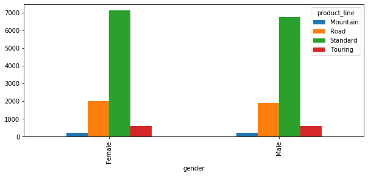

```python
join_df.groupby(['gender', 'product_line']).count()['profit'].unstack().plot(kind = 'bar',figsize = (10,4))
```

Generally, there is no significant difference in buying habit between male and female.

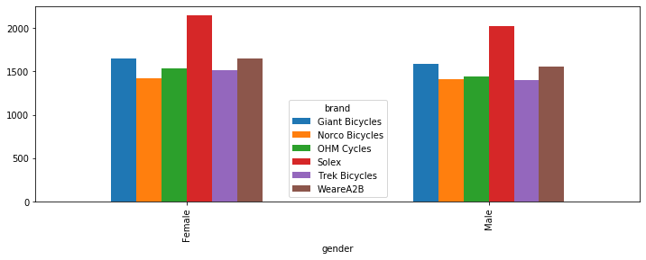

```python
join_df.groupby(['gender', 'brand']).count()['profit'].unstack().plot(kind = 'bar',figsize = (12,4))
```

Generally, there is no significant difference in brands' preference between male and female.

```python
join_df['profit'] = join_df.list_price - join_df.standard_cost
```

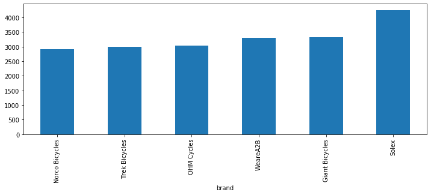

```python
join_df.groupby(['brand']).count().sort_values(['list_price'])['list_price'].plot(kind = 'bar', figsize = (12,4))
```

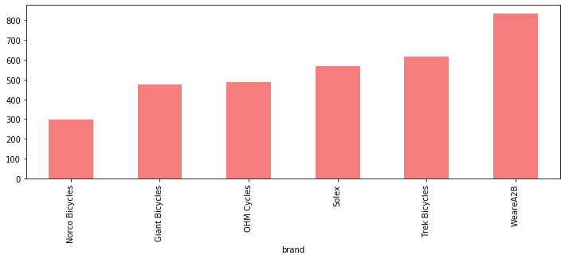

```python
join_df.groupby(['brand']).mean().sort_values(['profit'])['profit'].plot(kind = 'bar', figsize = (12,4),color = '#f67e7d')
```

The "Solex" brand brings the highest revenue, while the "WeareA2B" brand brings the highest profit.

```python
x = join_df.groupby(['brand','product_line']).mean()['profit'].unstack()
```

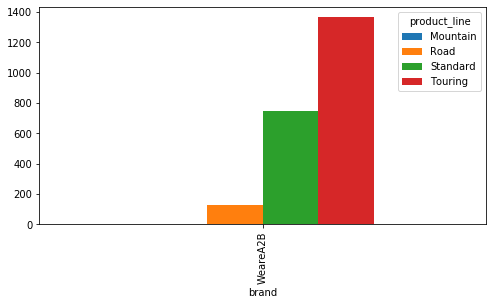

```python
x[x.index == 'WeareA2B'].plot(kind = 'bar', figsize = (8,4))
```

In the "WeareA2B" brand, touring bikes generates the highest profit.

```python
x1 = join_df.groupby(['wealth_segment']).count().sort_values(['profit'])
x2 = join_df.groupby(['wealth_segment']).mean().sort_values(['profit'])
```

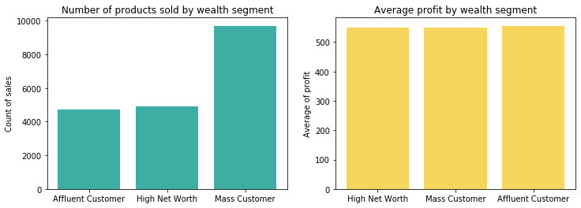

```python
plt.figure(figsize = (12,4))
plt.subplot(1,2,1)
plt.bar(x1.index,x1.profit, color = '#3CAEA3')
plt.title('Number of products sold by wealth segment')
plt.ylabel('Count of sales')
plt.subplot(1,2,2)
plt.bar(x2.index,x2.profit, color = '#F6D55C')
plt.title('Average profit by wealth segment')
plt.ylabel('Average of profit')
plt.show()
```

Even though Mass Customer type buys the highest number of products, the average profit generated by each wealth segment are relatively similar.

### In conclution, the company should:

- Invest in advertisement in both gender
- Try to push more sales in Touring and Standard bikes as they generate the highest profit margin
- Focus on the brands generaing the highest profit margin: WeareA2B, Trek Bicycles, and Solex
- Not focus solely on a certain range of age since the profit margin is the same across ages